# wineQualityWhites_EDA

```
##    Min. 1st Qu.  Median    Mean 3rd Qu.    Max.
##   2.720   3.090   3.180   3.188   3.280   3.820
```

pH的分部也是正态分布，大部分的数值在3.09-3.28之间，从已有的变量名字大体可以看出白葡萄酒中含有很多酸性物质，例如柠檬酸、各种硫化物、氯化物等

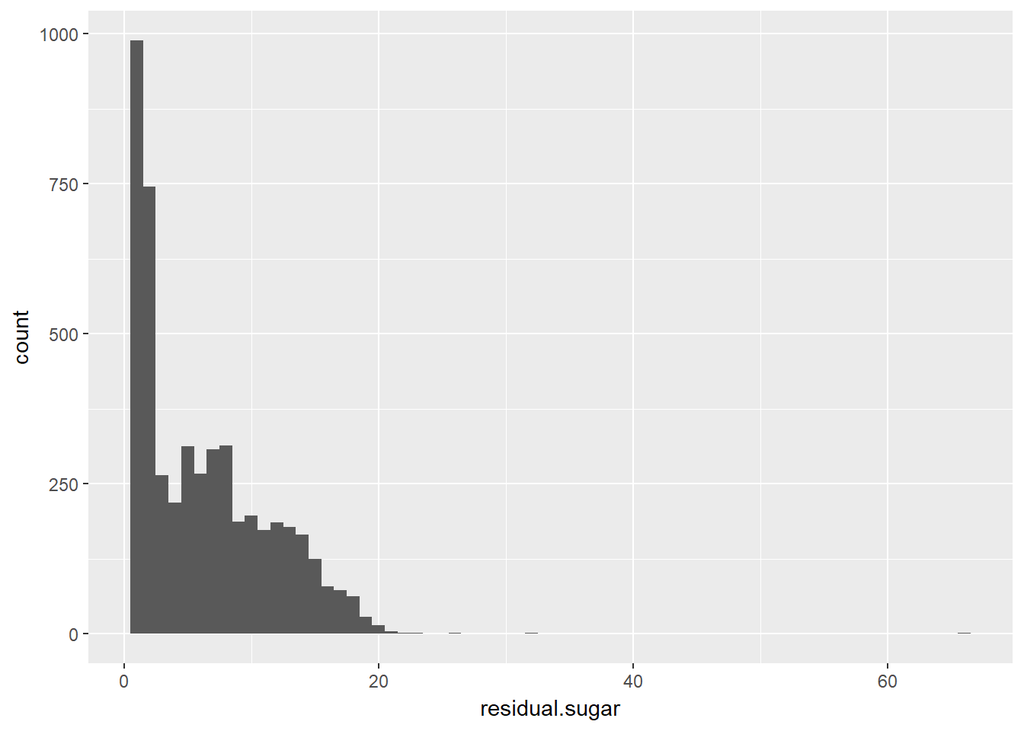

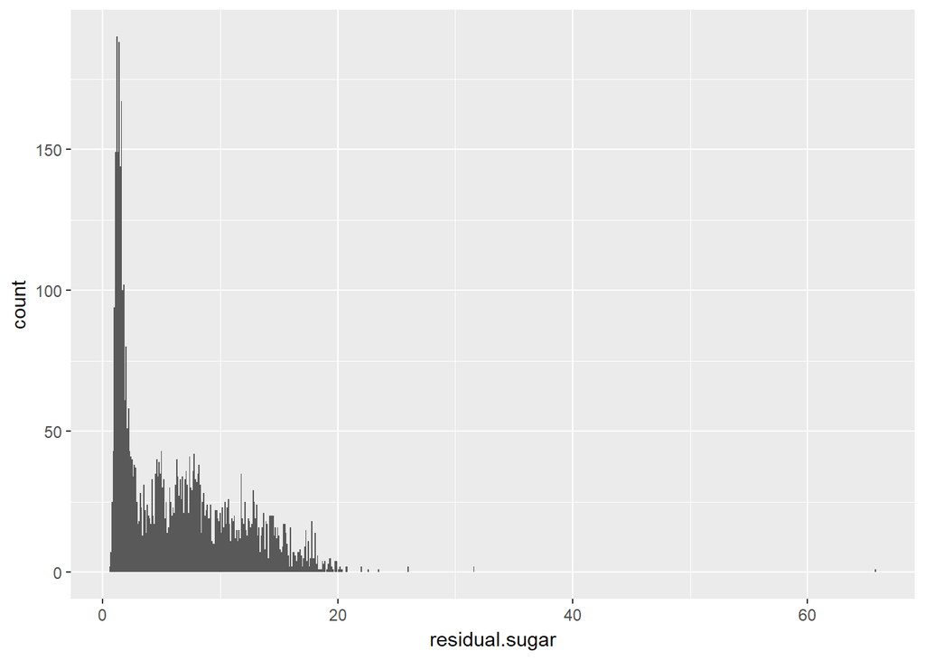

白葡萄酒中剩余糖分的含量分部是长尾，3以内的计数特别至高，对x轴使用对数坐标

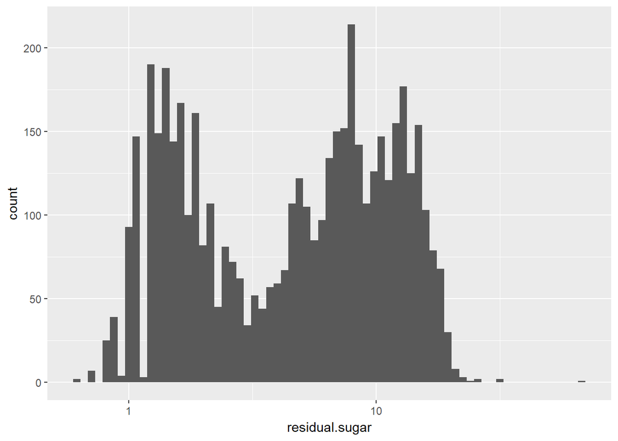

```
##    Min. 1st Qu.  Median    Mean 3rd Qu.    Max.
##   0.600   1.700   5.200   6.391   9.900  65.800
```

可以看到剩余糖分的含量大约在2和10处有两个峰值，而在3（对数坐标中1和10的中点处为3）处是一个谷

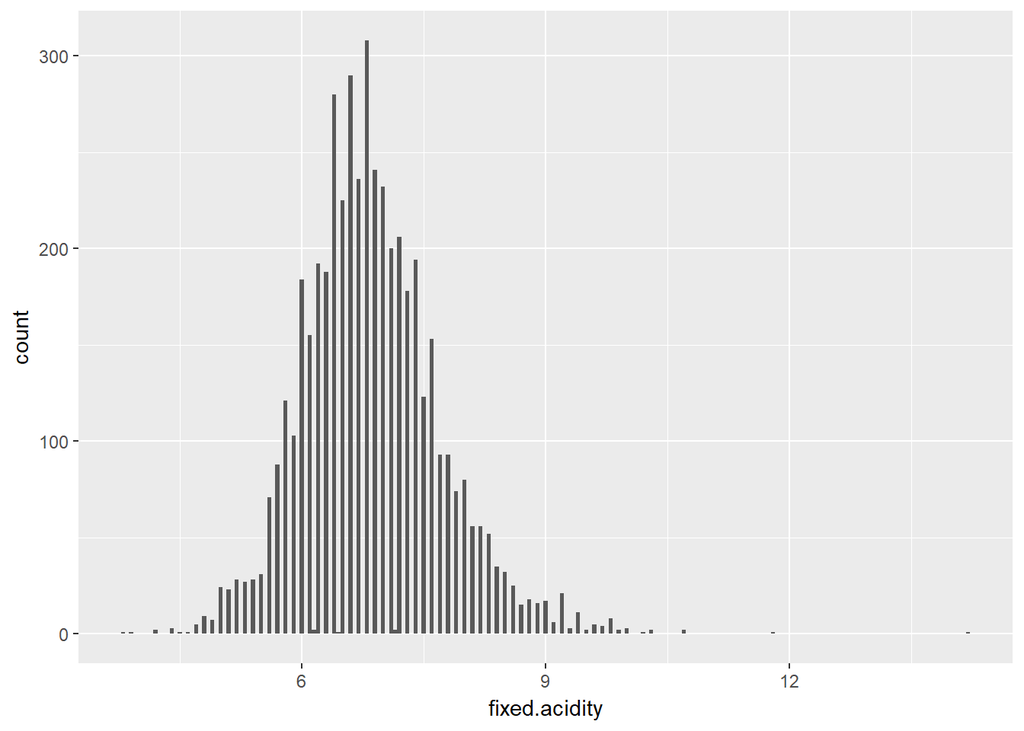

```
##    Min. 1st Qu.  Median    Mean 3rd Qu.    Max.
##   3.800   6.300   6.800   6.855   7.300  14.200
```

酒中的非挥发性的酸的分布大约是正态分布，大部分数据在6.3-7.3之间

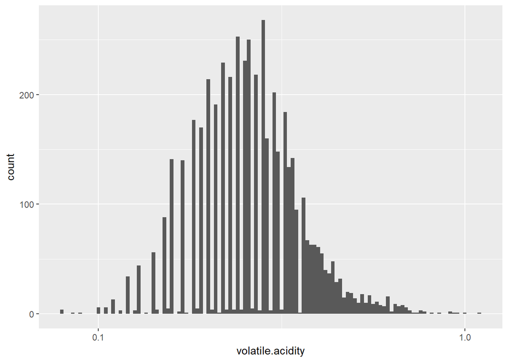

```
##    Min. 1st Qu.  Median    Mean 3rd Qu.    Max.
##  0.0800  0.2100  0.2600  0.2782  0.3200  1.1000
```

酒中的挥发性酸性物质的分布大体是正态分布，但是也有长尾数据，将其在对数坐标下显示柱状图，大部分的数据在0.21-0.32之间

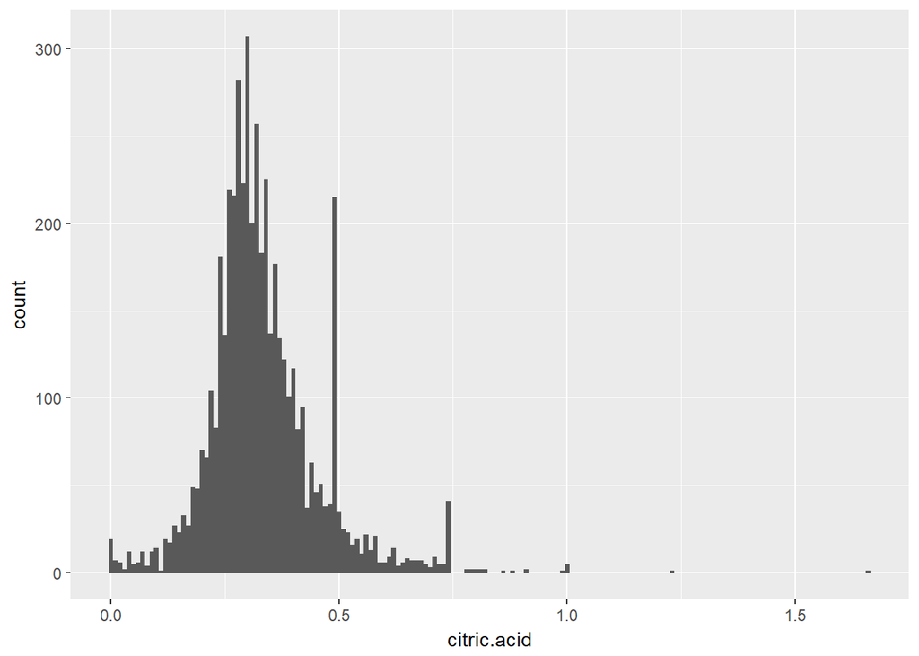

```
##    Min. 1st Qu.  Median    Mean 3rd Qu.    Max.
##  0.0000  0.2700  0.3200  0.3342  0.3900  1.6600
```

酒中的柠檬酸的含量大部分在0.27-0.39之间，在0.5左右有一个凸起值，有可能是异常值，需要稍微注意一下 这三个变量都是以酸的形式存在，将三个变量相加，得到白葡萄酒中酸性物质的总的含量

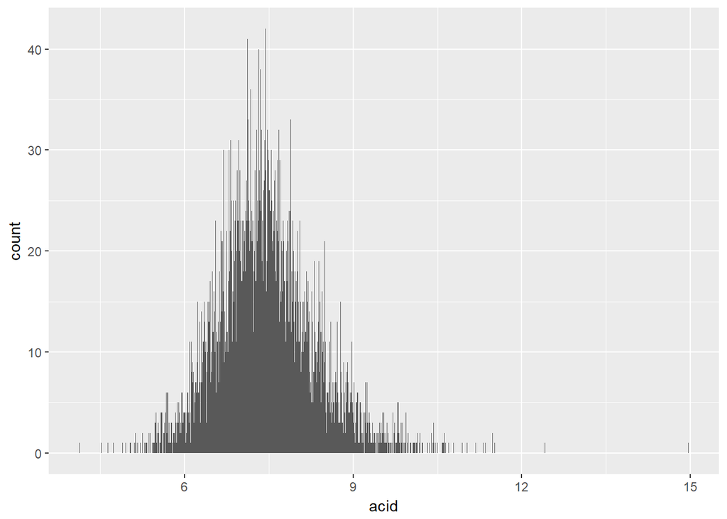

但是非挥发性酸性物质的数值明显要高于挥发性酸性物质和柠檬酸的数值，直接有可能削减挥发性酸性物质和柠檬酸的影响，因此使用离差标准化的方法定义标准化酸度为三个变量的离差标准化之和

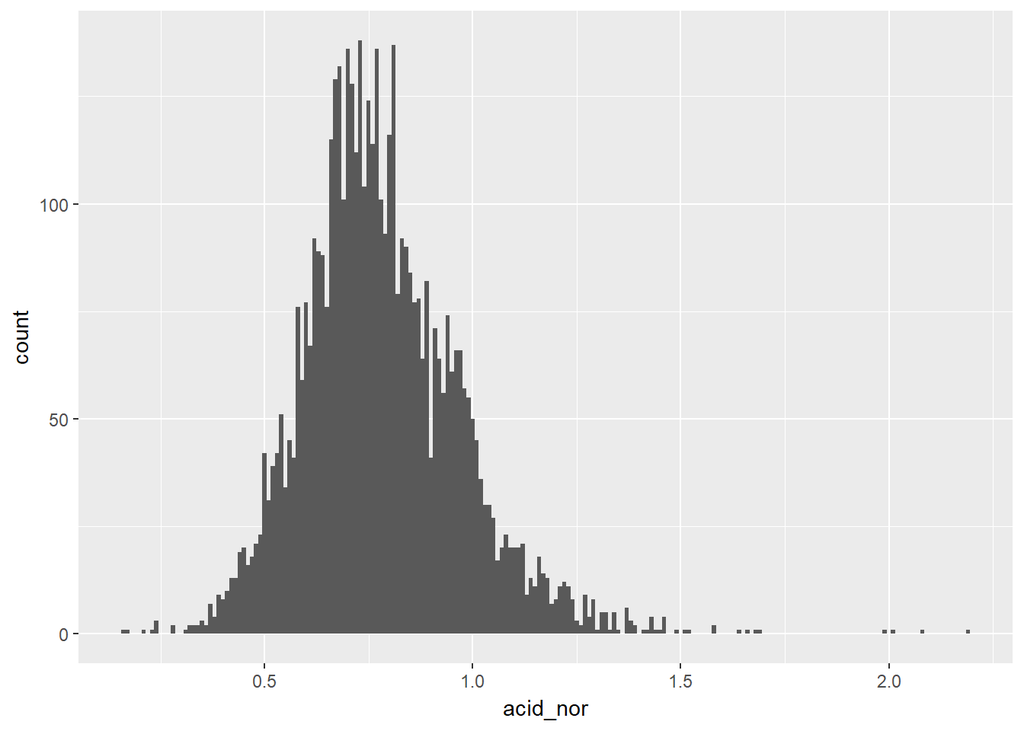

暂时看来与未调整之前的酸度值在分布上差别不是很大

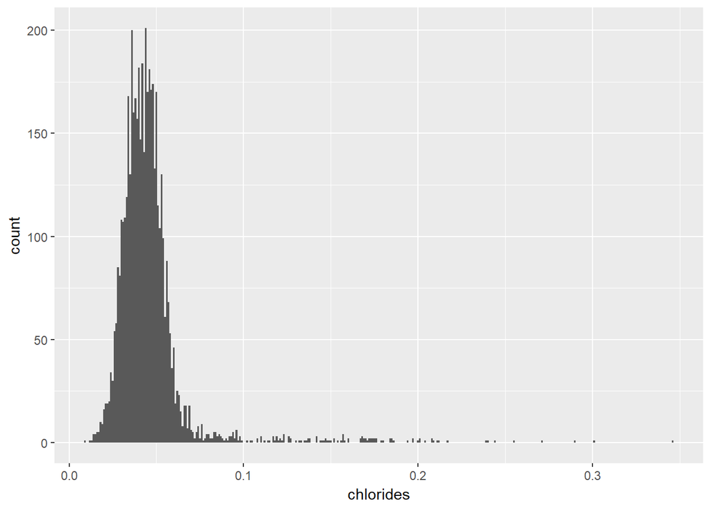

酸甜比也是衡量葡萄酒口感的一个很重的因素，创建酸甜比变量

查看其分布情况

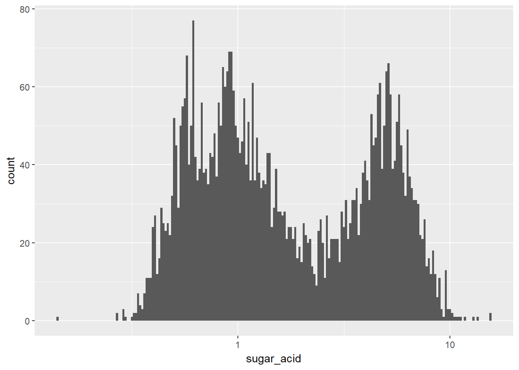

可以很明显的看出在1和5两个地方有峰值的存在

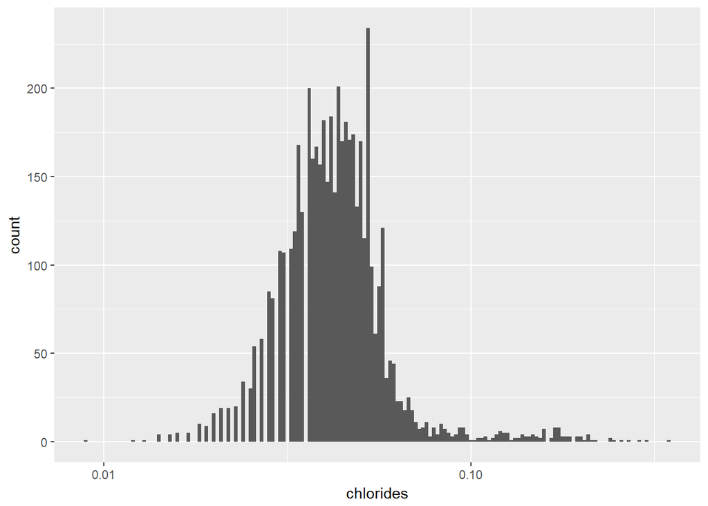

```
##    Min. 1st Qu.  Median    Mean 3rd Qu.    Max.
## 0.00900 0.03600 0.04300 0.04577 0.05000 0.34600
```

氯化物的分布有点类似于挥发性酸性物质的分布特点，两者之间可能会有一些潜在的联系

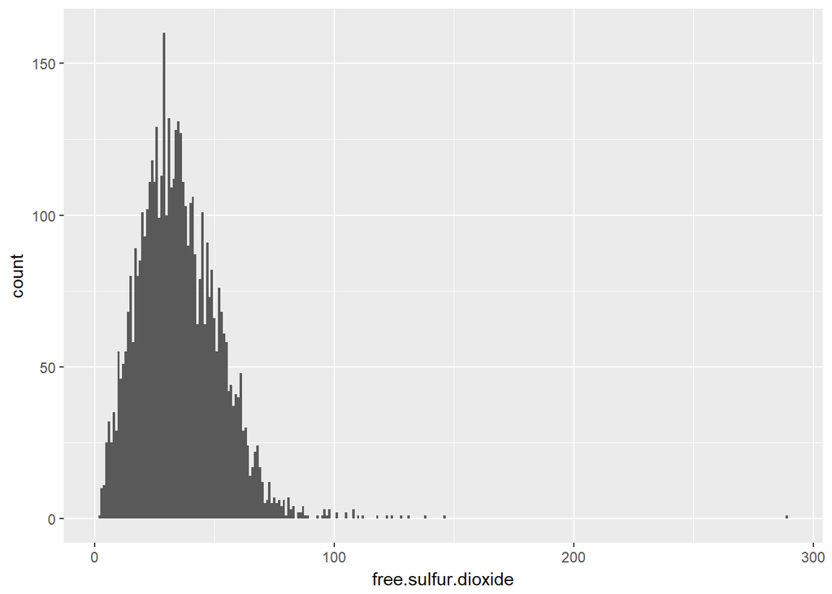

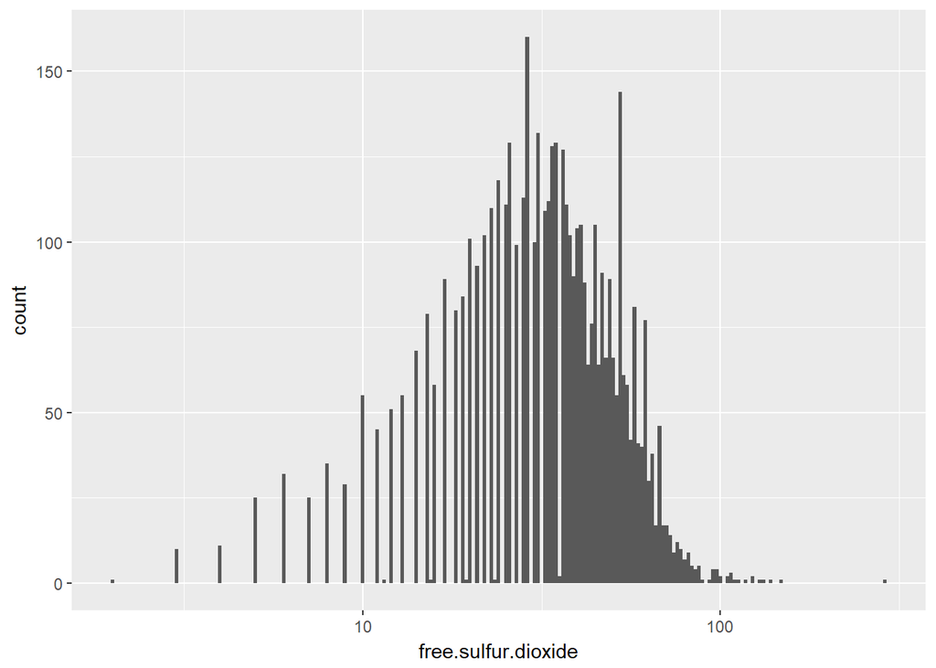

```
##    Min. 1st Qu.  Median    Mean 3rd Qu.    Max.
##    2.00   23.00   34.00   35.31   46.00  289.00
```

游离的二氧化硫的分布和挥发性酸性物质、氯化物的分布也有些类似

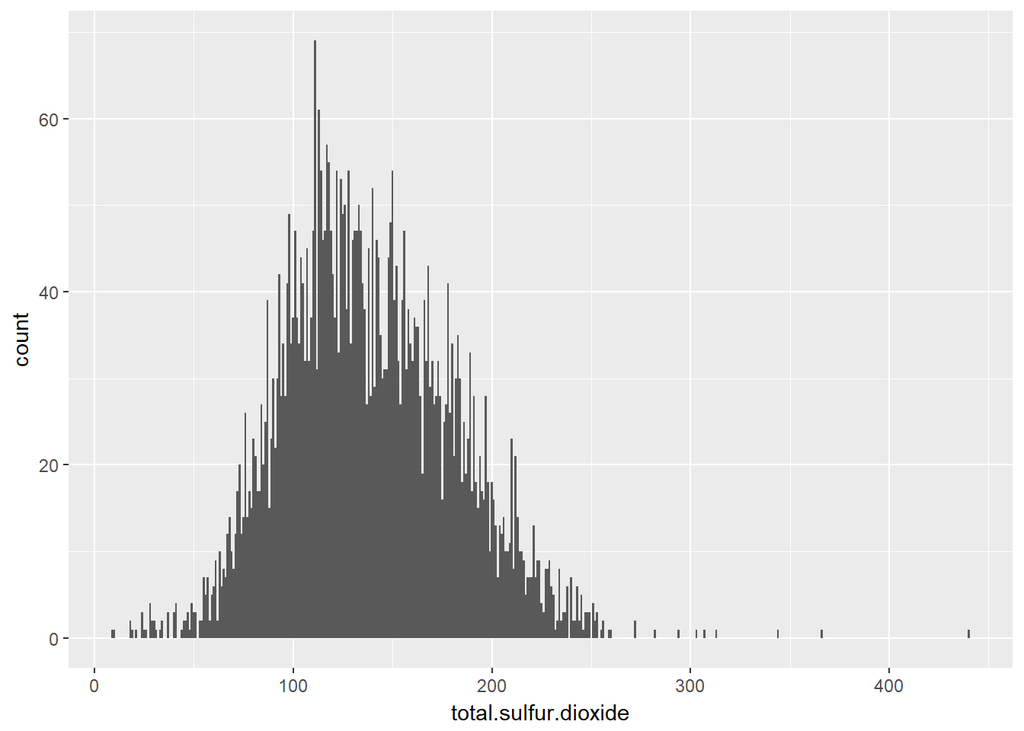